# Assignment 3: Part 1: Esoph

Can Aytöre / 2019702009

13/09/2020

# First Dataset of the Assignment 3: `esoph`

## Introduction

### Required Libraries

In order to examine this dataset, the following libraries are required and loaded. This dataset is already available in base-R under the name of `esoph`; therefore, there is no need for reading and loading the dataset.

```r
library(tidyverse)
library(ggplot2)
library(knitr)
```

### Overview of Dataset

- The data comes from a case-control study of Espophageal Cancer in France.
- Data was collected from 1175 patients with various age / alcohol / tobacco use combinations.
- Among 1175 patients, 200 cancer “cases” are included. Then 975 non-cases were sampled from comparable hospital populations.
- Data frame with records for 88 age / alcohol / tobacco combinations.

```r
glimpse(esoph)
```

```
## Rows: 88
## Columns: 5
## $ agegp     <ord> 25-34, 25-34, 25-34, 25-34, 25-34, 25-34, 25-34, 25-34, 2...
## $ alcgp     <ord> 0-39g/day, 0-39g/day, 0-39g/day, 0-39g/day, 40-79, 40-79,...
## $ tobgp     <ord> 0-9g/day, 10-19, 20-29, 30+, 0-9g/day, 10-19, 20-29, 30+,...
## $ ncases    <dbl> 0, 0, 0, 0, 0, 0, 0, 0, 0, 0, 0, 0, 1, 0, 0, 0, 1, 0, 0, ...
## $ ncontrols <dbl> 40, 10, 6, 5, 27, 7, 4, 7, 2, 1, 2, 1, 1, 1, 2, 60, 14, 7...
```

```r
summary(esoph)
```

```
##    agegp          alcgp         tobgp        ncases         ncontrols
##  25-34:15   0-39g/day:23   0-9g/day:24   Min.   : 0.000   Min.   : 1.00
##  35-44:15   40-79    :23   10-19   :24   1st Qu.: 0.000   1st Qu.: 3.00
##  45-54:16   80-119   :21   20-29   :20   Median : 1.000   Median : 6.00
##  55-64:16   120+     :21   30+     :20   Mean   : 2.273   Mean   :11.08
##  65-74:15                                3rd Qu.: 4.000   3rd Qu.:14.00
##  75+  :11                                Max.   :17.000   Max.   :60.00
```

### Objectives

- Exploring the dataset `esoph` which comes long in “R” package.
- Visualising the relationship between case occurrence and age / alcohol / tobacco profile.
- Identifying the groups at risk via useful analyzes and graphs.
- Building a well-developed generalized linear model.
- Predicting cancer percentages among the groups.
- Testing the robustness of the model via leave-one-out cross validation.

## Analyzes and Visualizations

### Overview

If the data set is small, sometimes a boxplot may not be very accurate, as the quartiles are not well estimated from the data and may give a falsely inflated or deflated figure. In those cases, plotting the raw data may be more desirable. This can be done using a strip chart.

#### Stripchart of Age Groups based on Number of Cases

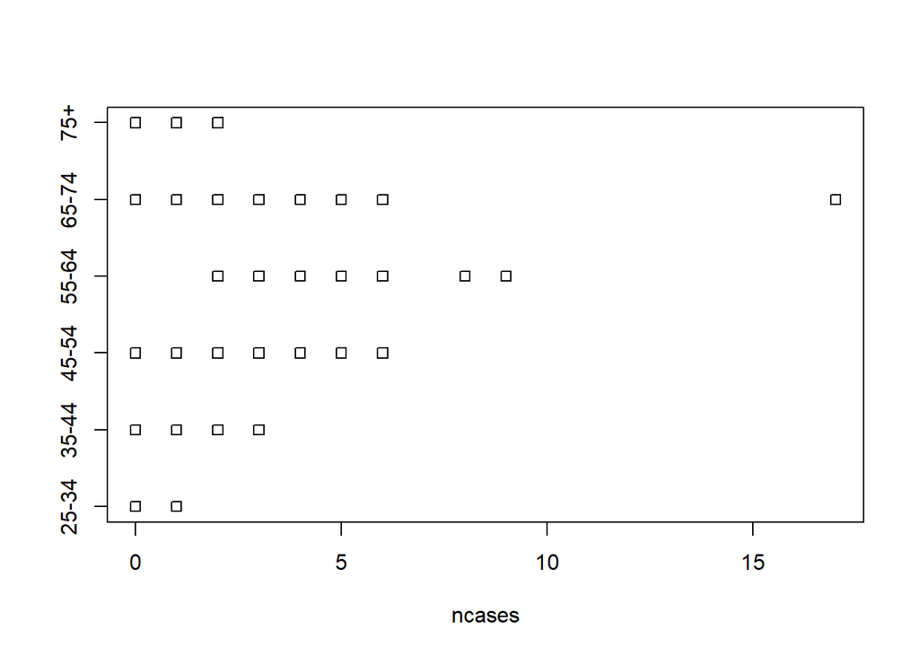

```r
stripchart(ncases ~ agegp, data=esoph)
```

- We can say that age groups have an effect on the number of cases.
- While there is at most 1 case in the 25-34 age group, that risk increases with age.
- The number of cases of 5 and more was seen in the age ranges of 45-74.

#### Stripchart of Tobacco Consumption based on Number of Cases

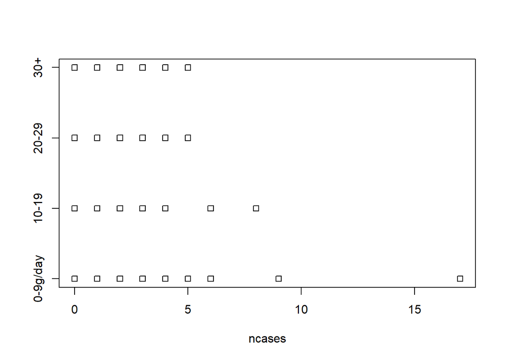

```r
stripchart(ncases ~ tobgp, data=esoph)
```

#### Stripchart of Alcohol Consumption based on Number of Cases

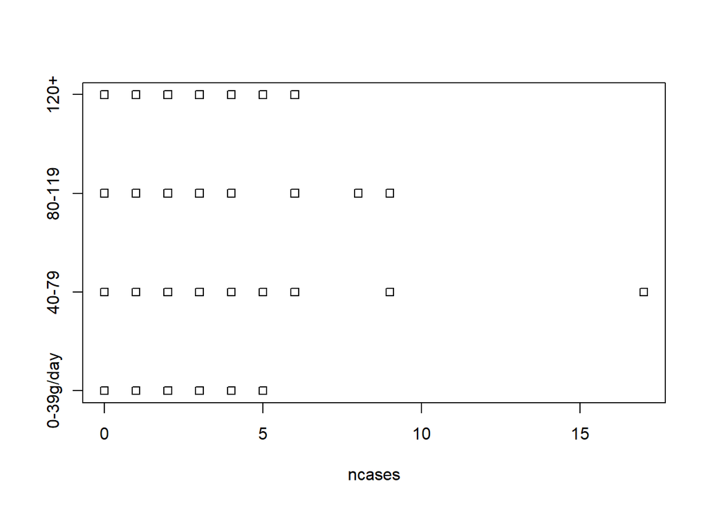

```r
stripchart(ncases ~ alcgp, data=esoph)
```

- We can say that alcohol use has an effect on the number of cases.
- The number of cases higher than 5 was seen in the groups of those who consumed more than 40g of alcohol per day.

We cannot get all inferences about the dataset just by looking at the stripcharts. More detailed analysis continues below.

### Cancer Proportion of Age Groups

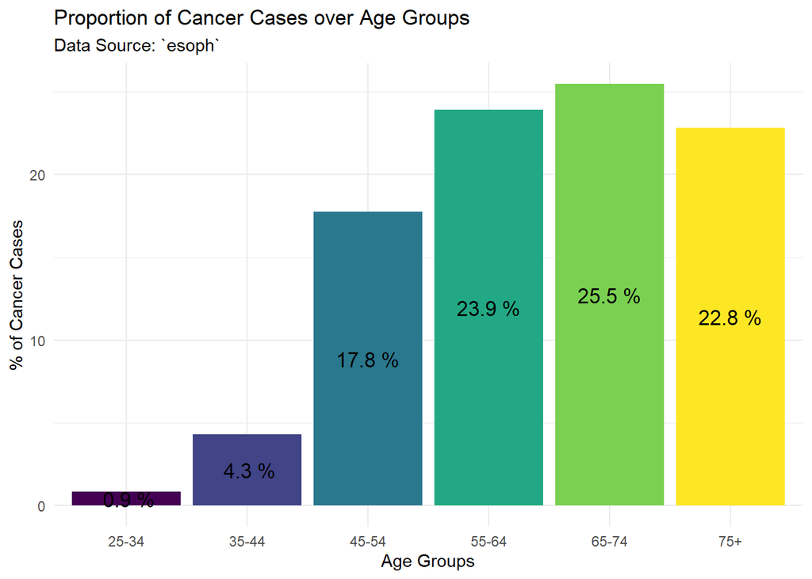

```r
esoph %>%
  group_by(agegp) %>%
  summarise(total_cases = sum(ncases),
            total_controls = sum(ncontrols),
            percentage = 100 * total_cases / (total_cases+total_controls)) %>%
  ggplot(., aes(x = agegp, y = percentage, fill = agegp)) +
  geom_bar(stat = "identity", position = "dodge") +
  labs(title = "Proportion of Cancer Cases over Age Groups", subtitle = "Data Source: `esoph`", x = 'Age Groups', y = "% of Cancer Cases") +
  theme_minimal() +
  theme(legend.position = "none") +
  geom_text(aes(label = paste(format(percentage,digits=1), "%")), size=4.5, position = position_stack(vjust = 0.5))
```

- As the age increases, the probability of seeing cases increases significantly.
- The highest risk is seen in the 65-74 age group.
- In the range of 25-44 ages, this risk is less than 5 percent.
- It has been observed that the risk has increased significantly since the age of 45.

### Cancer Proportion of Alcohol Consumption Groups

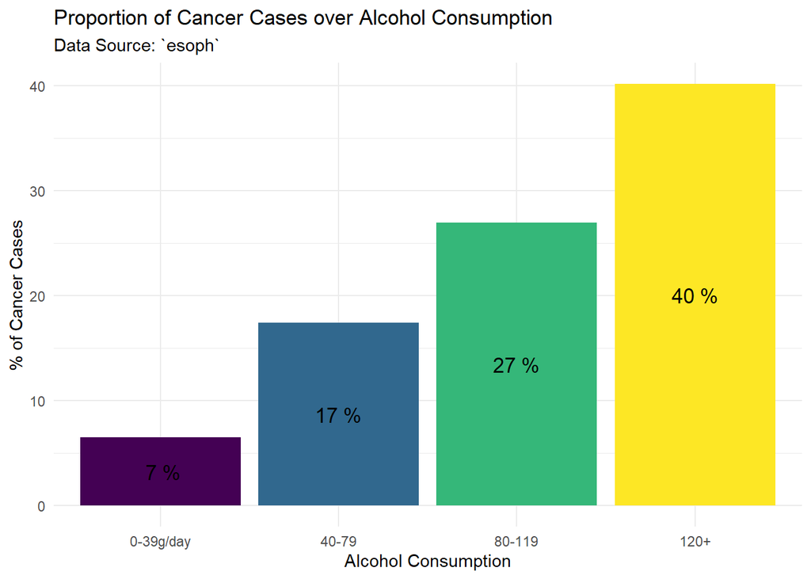

```r
esoph %>%
  group_by(alcgp) %>%
  summarise(total_cases = sum(ncases),
            total_controls = sum(ncontrols),
            percentage = 100 * total_cases / (total_cases+total_controls)) %>%
  ggplot(., aes(x = alcgp, y = percentage, fill = alcgp)) +
  geom_bar(stat = "identity", position = "dodge") +
  labs(title = "Proportion of Cancer Cases over Alcohol Consumption", subtitle = "Data Source: `esoph`", x = 'Alcohol Consumption', y = "% of Cancer Cases") +
  theme_minimal() +
  theme(legend.position = "none") +
  geom_text(aes(label = paste(format(percentage,digits=1), "%")), size=4.5, position = position_stack(vjust = 0.5))
```

- We can say that alcohol use has a very serious effect on the cancer proportion.
- As alcohol use increased, the risk increased in the same direction.
- While this risk is only 7 percent in the group with the least alcohol consumption, this risk is 40 percent in the group with the highest alcohol consumption.

### Cancer Proportion of Tobacco Consumption Groups

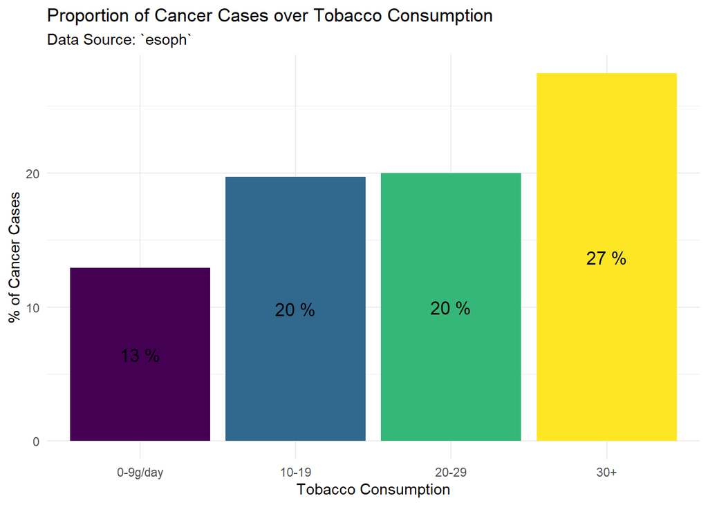

```r
esoph %>%
  group_by(tobgp) %>%
  summarise(total_cases = sum(ncases),
            total_controls = sum(ncontrols),
            percentage = 100 * total_cases / (total_cases+total_controls)) %>%
  ggplot(., aes(x = tobgp, y = percentage, fill = tobgp)) +
  geom_bar(stat = "identity", position = "dodge") +
  labs(title = "Proportion of Cancer Cases over Tobacco Consumption", subtitle = "Data Source: `esoph`", x = 'Tobacco Consumption', y = "% of Cancer Cases") +
  theme_minimal() +
  theme(legend.position = "none") +
  geom_text(aes(label = paste(format(percentage,digits=1), "%")), size=4.5, position = position_stack(vjust = 0.5))
```

- We can say that tobacco use has an effect on cancer percentages but not so serious.
- While the risk in the group with the least tobacco consumption was 13 percent, it was 27 percent in the group with the highest tobacco consumption.
- The risk is equal and 20 percent in groups consuming 10-19 and 20-29 grams of tobacco per day.

### Cancer Case Distribution of Alcohol Consumption by Age Group

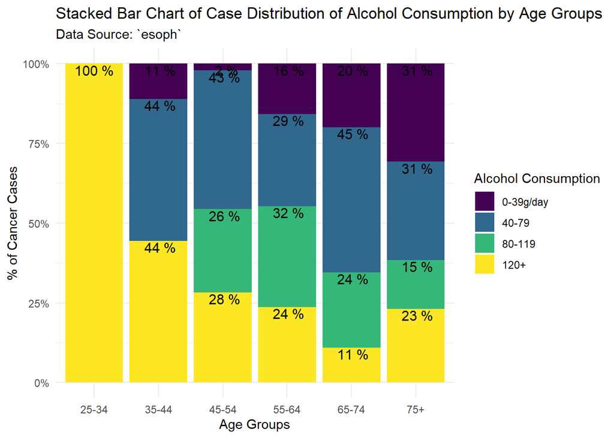

```r
esoph %>%
  select(-tobgp, -ncontrols) %>%
  group_by(agegp, alcgp) %>%
  summarize(total_cases = sum(ncases)) %>%
  group_by(agegp) %>%
  mutate(percentage = 100 * total_cases / sum(total_cases)) %>%
  filter(percentage != "NaN" & percentage != 0) %>%
  ggplot(., aes(x = agegp, y = percentage, fill = alcgp)) +
  geom_col(stat = "identity", position = "fill") +
  theme_minimal() +
  geom_text(aes(label = paste(format(percentage,digits=1), "%")), size=4, position = "fill", hjust = 0.5, vjust = 1.1) +
  scale_y_continuous(labels = scales::percent_format()) +
  labs(title = "Stacked Bar Chart of Case Distribution of Alcohol Consumption by Age Groups", subtitle = "Data Source: `esoph`", x = "Age Groups", y = "% of Cancer Cases", fill = "Alcohol Consumption")
```

### Cancer Case Distribution of Tobacco Consumption by Age Group

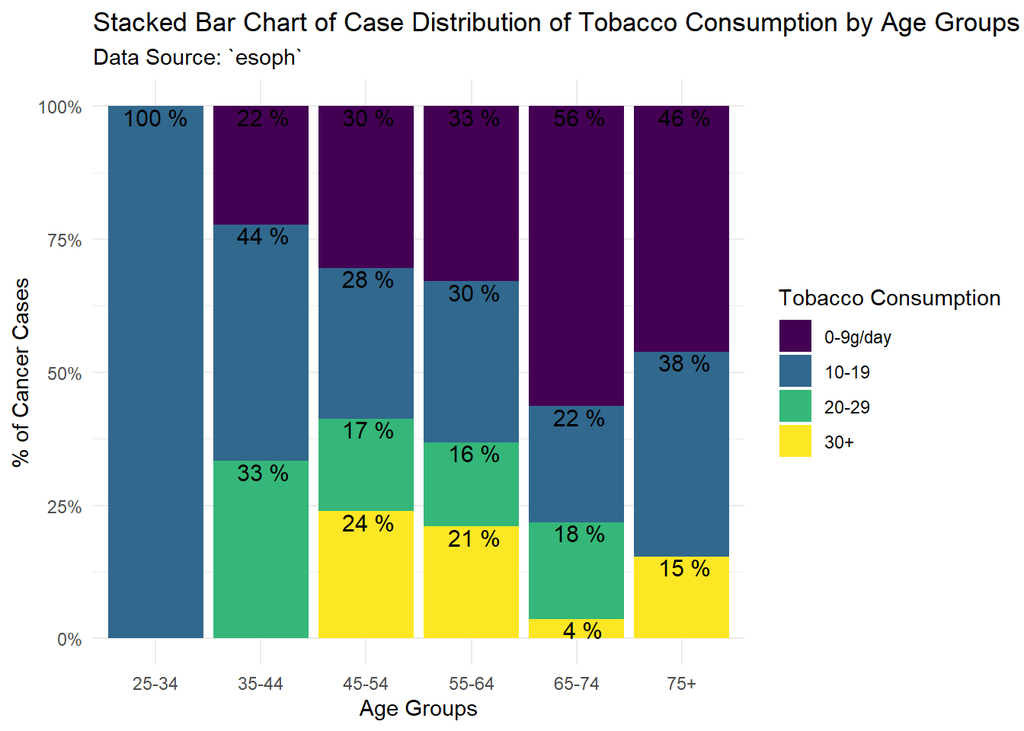

```r
esoph %>%
  select(-alcgp, -ncontrols) %>%
  group_by(agegp, tobgp) %>%
  summarize(total_cases = sum(ncases)) %>%
  group_by(agegp) %>%
  mutate(percentage = 100 * total_cases / sum(total_cases)) %>%
  filter(percentage != "NaN" & percentage != 0) %>%
  ggplot(., aes(x = agegp, y = percentage, fill = tobgp)) +
  geom_col(stat = "identity", position = "fill") +
  theme_minimal() +
  geom_text(aes(label = paste(format(percentage,digits=1), "%")), size=4, position = "fill", hjust = 0.5, vjust = 1.1) +
  scale_y_continuous(labels = scales::percent_format()) +
  labs(title = "Stacked Bar Chart of Case Distribution of Tobacco Consumption by Age Groups", subtitle = "Data Source: `esoph`", x = "Age Groups", y = "% of Cancer Cases", fill = "Tobacco Consumption")
```

- Groups that consume less tobacco in all age groups does not have a smaller share, while groups that consume the most alcohol generally have the smallest share. That’s why we cannot make significant inferences on cancer cases by considering tobacco consumption with age ranges together.
- Cases were observed only in the group that consumed more than 10-19 grams of tobacco per day in the age range of 25-34.
- It has been observed that those who consume less than 19 grams of tobacco per day have a significant share in all age groups.
- Looking at the stacked bar chart, excessive consumption of tobacco does not pose a serious risk.

### Cancer Case Distribution of Alcohol Consumption by Tobacco Consumption

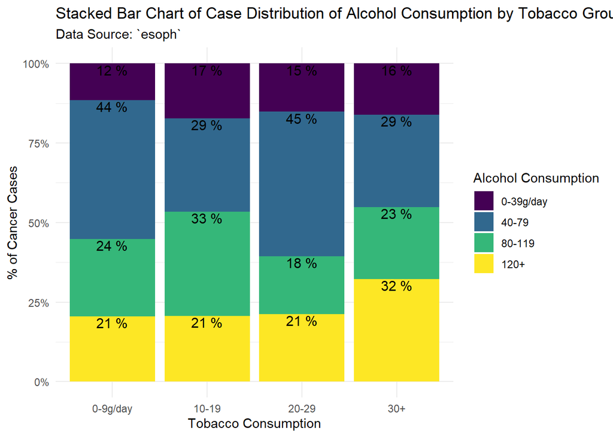

```r
esoph %>%
  select(-agegp, -ncontrols) %>%
  group_by(tobgp, alcgp) %>%
  summarize(total_cases = sum(ncases)) %>%
  group_by(tobgp) %>%
  mutate(percentage = 100 * total_cases / sum(total_cases)) %>%
  filter(percentage != "NaN" & percentage != 0) %>%
  ggplot(., aes(x = tobgp, y = percentage, fill = alcgp)) +
  geom_col(stat = "identity", position = "fill") +
  theme_minimal() +
  geom_text(aes(label = paste(format(percentage,digits=1), "%")), size=4, position = "fill", hjust = 0.5, vjust = 1.1) +
  scale_y_continuous(labels = scales::percent_format()) +
  labs(title = "Stacked Bar Chart of Case Distribution of Alcohol Consumption by Tobacco Groups", subtitle = "Data Source: `esoph`", x = "Tobacco Consumption", y = "% of Cancer Cases", fill = "Alcohol Consumption")
```

- According to tobacco consumption groups, the percentage of cases was lowest in the groups with the least alcohol consumption. (12 to 17 percent)
- Among those who consumed the least tobacco, the highest risk was the group consuming 40-79 grams of alcohol per day.
- Among those who consumed the most tobacco, the highest risk was the group consuming 120+ grams of alcohol per day.

### Cancer Case Distribution of Tobacco Consumption by Alcohol Consumption

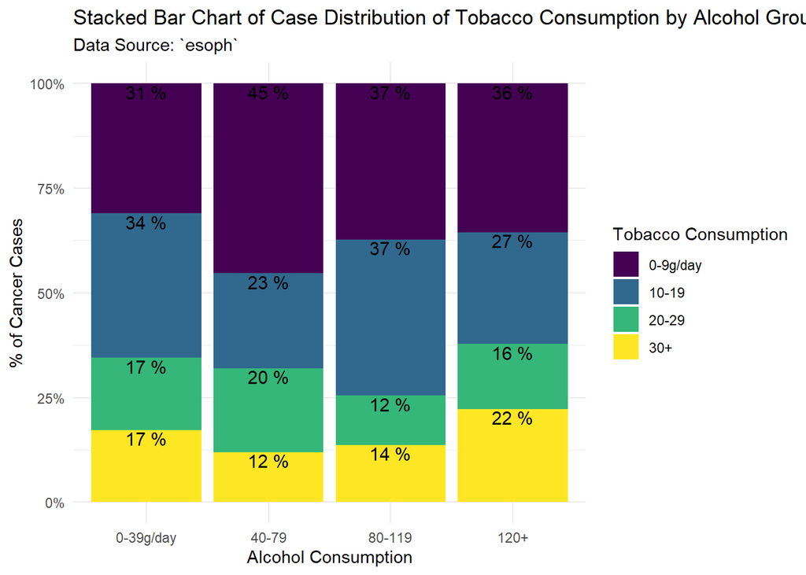

```r
esoph %>%
  select(-agegp, -ncontrols) %>%
  group_by(alcgp, tobgp) %>%
  summarize(total_cases = sum(ncases)) %>%
  group_by(alcgp) %>%
  mutate(percentage = 100 * total_cases / sum(total_cases)) %>%
  filter(percentage != "NaN" & percentage != 0) %>%
  ggplot(., aes(x = alcgp, y = percentage, fill = tobgp)) +
  geom_col(stat = "identity", position = "fill") +
  theme_minimal() +
  geom_text(aes(label = paste(format(percentage,digits=1), "%")), size=4, position = "fill", hjust = 0.5, vjust = 1.1) +
  scale_y_continuous(labels = scales::percent_format()) +
  labs(title = "Stacked Bar Chart of Case Distribution of Tobacco Consumption by Alcohol Groups", subtitle = "Data Source: `esoph`", x = "Alcohol Consumption", y = "% of Cancer Cases", fill = "Tobacco Consumption")
```

### Heatmap of Cancer Case Distribution

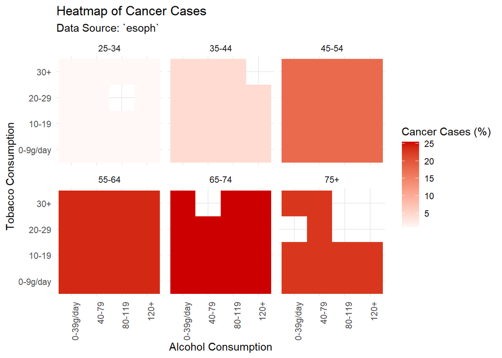

```r
esoph %>%
  group_by(agegp) %>%
  mutate(total_cases = sum(ncases),
            total_controls = sum(ncontrols),
            percentage = 100 * total_cases / (total_cases+total_controls)) %>%
  ggplot(., aes(x = alcgp, y = tobgp, fill = percentage)) +
  geom_tile() +
  facet_wrap(~agegp) +
  theme_minimal() +
  theme(axis.text.x = element_text(angle = 90, hjust = 1)) +
  scale_fill_gradient2(low="white", high="red3", guide="colorbar") +
  labs(title = "Heatmap of Cancer Cases", x = "Alcohol Consumption", subtitle = "Data Source: `esoph`", y = "Tobacco Consumption", fill = "Cancer Cases (%)")
```

### Jitterplot of Cancer Cases by Alcohol and Age Groups

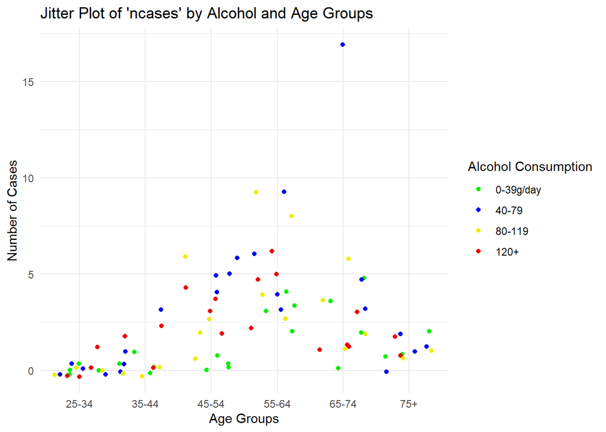

```r
ggplot(esoph, aes(x = as.factor(agegp), y = ncases, color = alcgp)) +
  geom_jitter(size=1.5, position = position_jitter(width = 0.4)) +
  theme_minimal() +
  scale_color_manual(values=c("green2", "blue2", "yellow2", "red2")) +
  labs(title = "Jitter Plot of 'ncases' by Alcohol and Age Groups", x = "Age Groups", y = "Number of Cases", color = "Alcohol Consumption")
```

- The number of cases is at the lowest levels in the age range of 25-34.
- The highest number of cases occurred in the 40-79 grams of alcohol consumption group per day (blue dotted) in the range of 65-74 ages.
- In all age groups, the lowest number of cases were generally observed in the groups with the least alcohol consumption (green dotted).

### Mosaicplot of Cancer Case Distribution

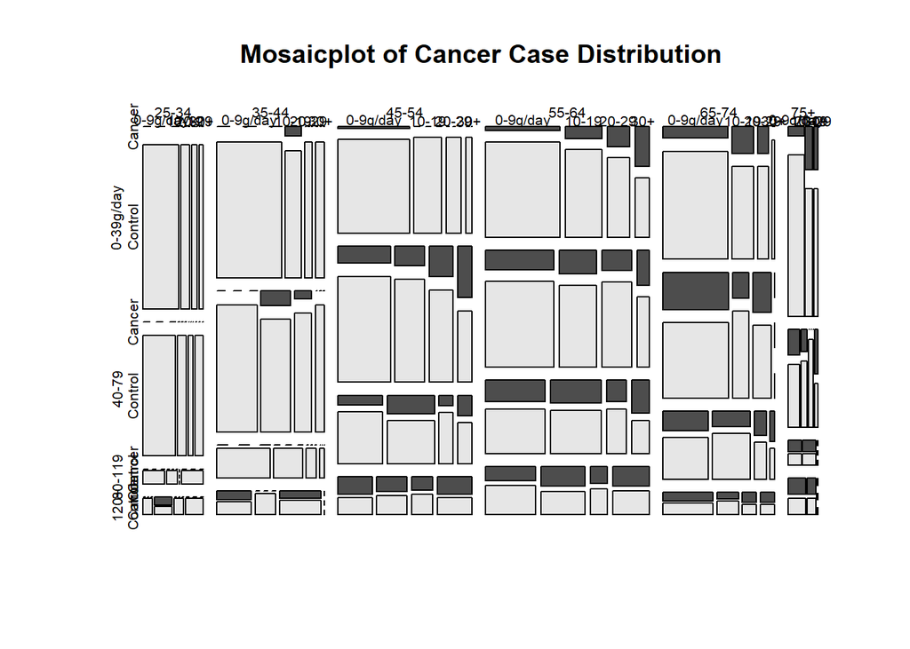

```r
require(graphics) # for mosaicplot
## Re-arrange data for a mosaic plot
ttt <- table(esoph$agegp, esoph$alcgp, esoph$tobgp)
o <- with(esoph, order(tobgp, alcgp, agegp))
ttt[ttt == 1] <- esoph$ncases[o]
tt1 <- table(esoph$agegp, esoph$alcgp, esoph$tobgp)
tt1[tt1 == 1] <- esoph$ncontrols[o]
tt <- array(c(ttt, tt1), c(dim(ttt),2),
            c(dimnames(ttt), list(c("Cancer", "Control"))))
mosaicplot(tt, main = "Mosaicplot of Cancer Case Distribution", color = TRUE)
```

## Generalized Linear Model

### ANOVA Test

```r
esoph$percentage <- esoph$ncases / (esoph$ncontrols+esoph$ncases) #The new column is created to show the cancer percentages
model <- lm(percentage ~ agegp + tobgp + alcgp, data = esoph) #Linear model is created in order to apply anova test
anova(model)
```

```
## Analysis of Variance Table
##
## Response: percentage
##           Df  Sum Sq  Mean Sq F value    Pr(>F)
## agegp      5 1.23742 0.247484 19.4982 1.918e-12 ***
## tobgp      3 0.03361 0.011205  0.8828     0.454
## alcgp      3 0.86514 0.288381 22.7203 1.333e-10 ***
## Residuals 76 0.96464 0.012693
## ---
## Signif. codes:  0 '***' 0.001 '**' 0.01 '*' 0.05 '.' 0.1 ' ' 1
```

According to the results of the ANOVA test, it was observed that while age and alcohol groups had a serious effect, tobacco groups did not make a significant difference with the p-value 45%.

### Akaike’s Information Criterion

To build a better model, we can decide whether we should remove tobacco groups from our model by looking at the AIC values.

```r
AIC(glm(percentage ~ agegp + tobgp + alcgp, data = esoph, family = binomial(link = "logit"))) #With tobacco groups
```

```
## [1] 69.62955
```

```r
AIC(glm(percentage ~ agegp + alcgp, data = esoph, family = binomial(link = "logit"))) #Without tobacco groups
```

```
## [1] 63.43588
```

AIC (Akaike’s Information Criterion) allows to compare models with different distributions and with different number of parameters. The best fitting model is the model with the smallest AIC-value. When we remove the tobacco group from our model, we see a serious decrease in AIC value. Therefore, we will proceed without adding tobacco groups to our model.

### Logistic Regression

```r
model <- glm(percentage ~ agegp + alcgp, data = esoph, family = binomial(link = "logit")) #Logistic regression
summary(model)
```

```
##
## Call:
## glm(formula = percentage ~ agegp + alcgp, family = binomial(link = "logit"),
##     data = esoph)
##
## Deviance Residuals:
##     Min       1Q   Median       3Q      Max
## -0.8486  -0.2650  -0.1225   0.1672   1.1824
##
## Coefficients:
##             Estimate Std. Error z value Pr(>|z|)
## (Intercept) -1.69863    0.37820  -4.491 7.08e-06 ***
## agegp.L      2.45976    1.06194   2.316   0.0205 *
## agegp.Q     -0.94555    0.95610  -0.989   0.3227
## agegp.C     -0.01623    0.90430  -0.018   0.9857
## agegp^4      0.44297    0.81404   0.544   0.5863
## agegp^5     -0.17601    0.65825  -0.267   0.7892
## alcgp.L      1.41043    0.64271   2.195   0.0282 *
## alcgp.Q     -0.09357    0.60333  -0.155   0.8768
## alcgp.C      0.16453    0.56916   0.289   0.7725
## ---
## Signif. codes:  0 '***' 0.001 '**' 0.01 '*' 0.05 '.' 0.1 ' ' 1
##
## (Dispersion parameter for binomial family taken to be 1)
##
##     Null deviance: 23.2729  on 87  degrees of freedom
## Residual deviance:  8.5657  on 79  degrees of freedom
## AIC: 63.436
##
## Number of Fisher Scoring iterations: 6
```

- Here is the summary of logistic regression.
- There are catogeries with a p-value of less than 5 percent, so we can proceed with this model.
- We can predict the cancer percentages according to this model, and then we can draw the error histogram by comparing it with actual values.

### Predicted Cancer Risk Percentages among Alcohol and Age Groups

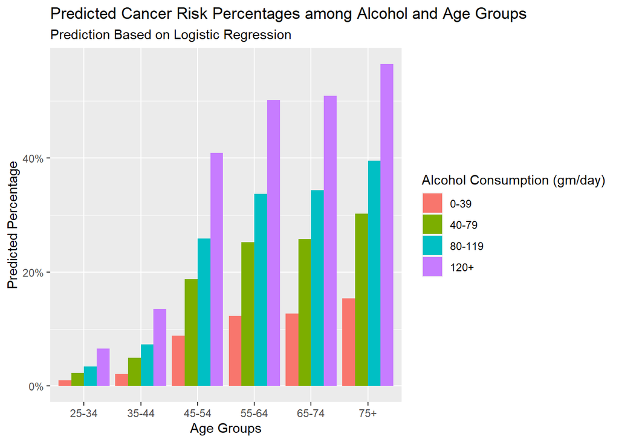

```r
predict_cancer_percentages <- data.frame()
for (i in 1:6) {
  for (j in 1:4) {
    predict_cancer_percentages[i,j] <- plogis(predict(model, data.frame(agegp = unique(esoph$agegp)[i], alcgp = unique(esoph$alcgp)[j]))) #Prediction
  }
}
pivot_longer(predict_cancer_percentages, cols=everything(), names_to = "Alcohol_Consumption", values_to = "Cancer_Percentage") %>%
  add_column(.before="Alcohol_Consumption", Age_Group = c(rep("25-34",4),rep("35-44",4),rep("45-54",4),rep("55-64",4),rep("65-74",4),rep("75+",4))) %>%
  ggplot(.,aes(x=Age_Group, y=Cancer_Percentage, fill = Alcohol_Consumption)) +
  geom_bar(stat = "identity", position = "dodge") +
  scale_y_continuous(labels = scales::percent_format()) +
  scale_fill_discrete(name = "Alcohol Consumption (gm/day)", labels = c("0-39", "40-79", "80-119", "120+")) +
  labs(title = "Predicted Cancer Risk Percentages among Alcohol and Age Groups", subtitle = "Prediction Based on Logistic Regression", x = "Age Groups", y = "Predicted Percentage")
```

- Above, you can graphically see the estimated cancer percentages by age and alcohol groups. You can see the percentage values in the table below.
- The increase in alcohol consumption has increased the risk level in all age groups. Likewise, risk levels increased with increasing age.
- The risk is very low in the 25-34 and 35-44 age groups.
- Since the age of 45, the risk increases significantly.
- The risk levels in the 55-64 and 65-74 age groups are very similar.
- The highest risks were observed in the age range above 75.
- In case of low consumption of alcohol, there is a risk of at most 15 percent (group over 75 years old). In case of excessive consumption of alcohol, this risk increases up to 56 percent. Therefore, reducing alcohol consumption significantly reduces the risk of cancer.

```r
predict_cancer_percentages <- data.frame(row.names = c("25-34 years","35-44 years","45-54 years","55-64 years","65-74 years","75+ years"))
for (i in 1:6) {
  for (j in 1:4) {
    predict_cancer_percentages[i,j] <- paste(round(100*(plogis(predict(model, data.frame(agegp = unique(esoph$agegp)[i], alcgp = unique(esoph$alcgp)[j])))),0),"%",sep="")
  }
}
colnames(predict_cancer_percentages) <- c("0-39 gm/day","40-79 gm/day","80-119 gm/day","120+ gm/day")
kable(predict_cancer_percentages, caption = "Predicted Cancer Percentages corresp. to Age and Alcohol Groups")
```

Predicted Cancer Percentages corresp. to Age and Alcohol Groups

|  | 0-39 gm/day | 40-79 gm/day | 80-119 gm/day | 120+ gm/day |
| --- | --- | --- | --- | --- |
| 25-34 years | 1% | 2% | 3% | 7% |
| 35-44 years | 2% | 5% | 7% | 14% |
| 45-54 years | 9% | 19% | 26% | 41% |
| 55-64 years | 12% | 25% | 34% | 50% |
| 65-74 years | 13% | 26% | 34% | 51% |
| 75+ years | 15% | 30% | 40% | 56% |

### Leave-one-out Cross Validation

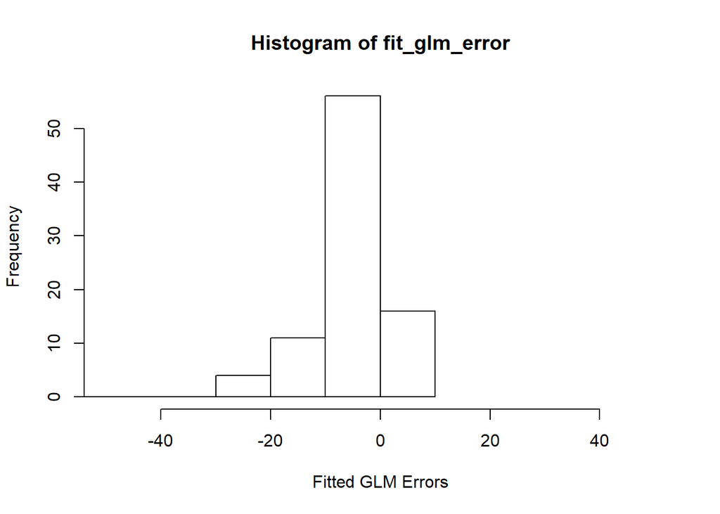

```r
pred_length <- nrow(esoph)
fit_glm_error <- c()
fit_glm_sq_error <- c()
for(i in 1:pred_length){
  fit_glm <- glm(percentage ~ agegp + alcgp, family = binomial(link = "logit"), data = esoph[-i,]) #Leave-one-out Cross Validation
  fit_glm_pred <- (predict(fit_glm, esoph[i,]))^2
  fit_glm_error[i] <- esoph$percentage[i] - fit_glm_pred
  fit_glm_sq_error[i] = (esoph$percentage[i] - fit_glm_pred)^2
}
hist(fit_glm_error, breaks = 50, xlim = range(-50,50), title = "Histogram of Errors", xlab = "Fitted GLM Errors")
```

```r
rmse_fit_glm <- sqrt(mean(fit_glm_sq_error))
rmse_fit_glm #Root Mean Square Error
```

[output not shown]

# References

- [Logistic Regression](https://www.datacamp.com/community/tutorials/logistic-regression-R)
- [Akaike information criterion](https://en.wikipedia.org/wiki/Akaike_information_criterion)
- Leave-one-out Cross Validation

# Second Part of the Assignment: `Young People Survey`

*[Click here in order to see the second part of the assignment where I reviewed another dataset `Young People Survey`](https://pjournal.github.io/boun01-canaytore/assignment3_survey)*